# Analise Exploratoria

Lucas Terciotti

```r
library(tidyverse)
library(ggplot2)
library(rpart)
library(Amelia)
```

Para inciar a análise, retiraramos os dados do repositório no GitHub:

```r
titanic <- read.csv(("https://raw.githubusercontent.com/Efsilvaa/EPSMLRepo/master/Data/titanic.csv"),
                    stringsAsFactors=FALSE,
                    na.strings = c(""))
str(titanic)
```

```
## 'data.frame':    891 obs. of  12 variables:
##  $ PassengerId: int  1 2 3 4 5 6 7 8 9 10 ...
##  $ Survived   : int  0 1 1 1 0 0 0 0 1 1 ...
##  $ Pclass     : int  3 1 3 1 3 3 1 3 3 2 ...
##  $ Name       : chr  "Braund, Mr. Owen Harris" "Cumings, Mrs. John Bradley (Florence Briggs Thayer)" "Heikkinen, Miss. Laina" "Futrelle, Mrs. Jacques Heath (Lily May Peel)" ...
##  $ Sex        : chr  "male" "female" "female" "female" ...
##  $ Age        : num  22 38 26 35 35 NA 54 2 27 14 ...
##  $ SibSp      : int  1 1 0 1 0 0 0 3 0 1 ...
##  $ Parch      : int  0 0 0 0 0 0 0 1 2 0 ...
##  $ Ticket     : chr  "A/5 21171" "PC 17599" "STON/O2. 3101282" "113803" ...
##  $ Fare       : num  7.25 71.28 7.92 53.1 8.05 ...
##  $ Cabin      : chr  NA "C85" NA "C123" ...
##  $ Embarked   : chr  "S" "C" "S" "S" ...
```

# Preparação dos dados:

A intenção inicial é ocupar os dados ausentes de colunas relevantes com informações úteis para a análise e colocar as variáveis categoricas como fatores.

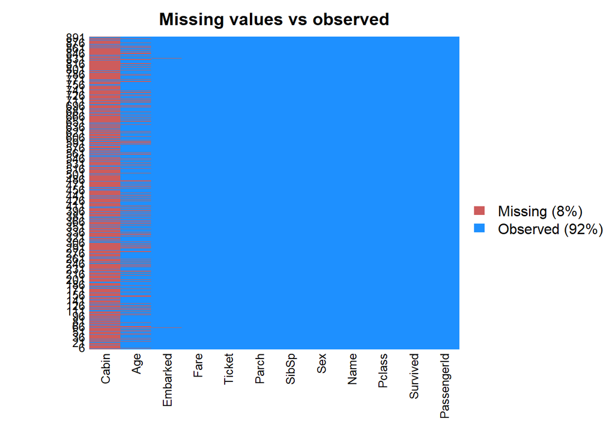

```r
missmap(titanic, main = "Missing values vs observed")
```

Primeiramente, alteramos a coluna “Survived” para fator, para facilitar a avaliação das informações contidas nessa variável:

```r
titanic$Survived <- as.factor(titanic$Survived)
summary(titanic$Survived)
```

```
##   0   1
## 549 342
```

Depois, a coluna Embarked também foi transformada e seus espaços desconhecidos preenchidos com “S”. Foi decidido por tomar essa decisão, pois eram pouquíssimos valores ausentes e “S” o fator mais comum na avaliação.

```r
titanic$Embarked <- as.factor(titanic$Embarked)
titanic$Embarked[is.na(titanic$Embarked)] = "S"
titanic$Embarked <- factor(titanic$Embarked)
summary(titanic$Embarked)
```

```
##   C   Q   S
## 168  77 646
```

Sexo tmabém apresenta-se como uma variável categorica, entretanto é classificada no resumo dos dados como caracter.

```r
titanic$Sex <- as.factor(titanic$Sex)
contrasts(titanic$Sex)
```

```
##        male
## female    0
## male      1
```

Após a aula de random forest, os dados ausentes referentes à idade foram preenchidos com uma previsão, que pode ser vista a seguir:

```r
Agefit <- rpart(Age ~ Pclass + Sex + SibSp +
                  Parch + Fare + Embarked,
                data=titanic[!is.na(titanic$Age),],
                method="anova")

titanic$Age[is.na(titanic$Age)] <-

  predict(Agefit, titanic[is.na(titanic$Age),])

summary(titanic$Age)
```

```
##    Min. 1st Qu.  Median    Mean 3rd Qu.    Max.
##    0.42   21.53   27.84   29.56   37.00   80.00
```

Como podemos analisar, os dados foram devidamente preenchidos (excluindo-se a coluna referente à cabine):

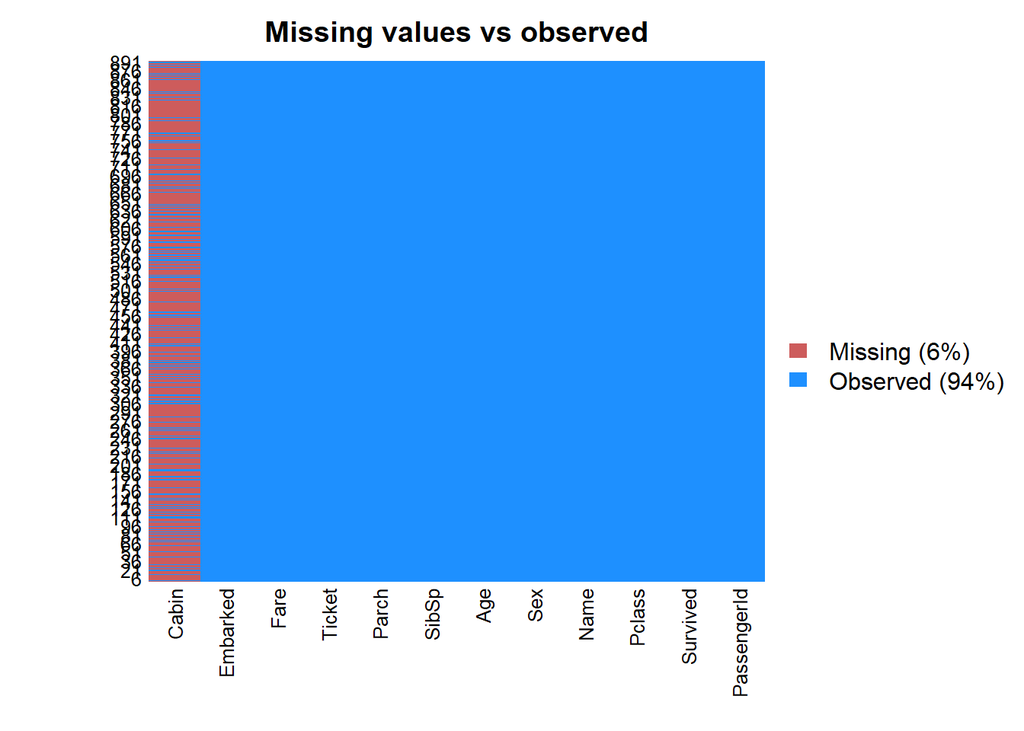

```r
missmap(titanic, main = "Missing values vs observed")
```

# Análise dos dados:

### Curiosidade:

Quais os sobreviventes de 30 anos?

```r
filter(titanic, Survived == 1, Age == 30) #permite filtrar os dados para alcançar informações específicas
```

```
##    PassengerId Survived Pclass                                        Name
## 1           80        1      3                    Dowdell, Miss. Elizabeth
## 2          258        1      1                        Cherry, Miss. Gladys
## 3          287        1      3                     de Mulder, Mr. Theodore
## 4          310        1      1              Francatelli, Miss. Laura Mabel
## 5          323        1      2                   Slayter, Miss. Hilda Mary
## 6          521        1      1                       Perreault, Miss. Anne
## 7          538        1      1                         LeRoy, Miss. Bertha
## 8          727        1      2 Renouf, Mrs. Peter Henry (Lillian Jefferys)
## 9          748        1      2                       Sinkkonen, Miss. Anna
## 10         843        1      1                     Serepeca, Miss. Augusta
##       Sex Age SibSp Parch   Ticket     Fare Cabin Embarked
## 1  female  30     0     0   364516  12.4750  <NA>        S
## 2  female  30     0     0   110152  86.5000   B77        S
## 3    male  30     0     0   345774   9.5000  <NA>        S
## 4  female  30     0     0 PC 17485  56.9292   E36        C
## 5  female  30     0     0   234818  12.3500  <NA>        Q
## 6  female  30     0     0    12749  93.5000   B73        S
## 7  female  30     0     0 PC 17761 106.4250  <NA>        C
## 8  female  30     3     0    31027  21.0000  <NA>        S
## 9  female  30     0     0   250648  13.0000  <NA>        S
## 10 female  30     0     0   113798  31.0000  <NA>        C
```

### Curiosidade:

Qual a média de idade dos que morreram? e dos que sobreviveram?

```r
Alive <- group_by(titanic, Survived)
summarise(Alive, Age = mean(Age, na.rm = TRUE))
```

```
## # A tibble: 2 x 2
##   Survived   Age
##   <fct>    <dbl>
## 1 0         30.0
## 2 1         28.8
```

### Metricas basicas:

Six number summary

```r
summary(titanic)
```

```
##   PassengerId    Survived     Pclass          Name               Sex
##  Min.   :  1.0   0:549    Min.   :1.000   Length:891         female:314
##  1st Qu.:223.5   1:342    1st Qu.:2.000   Class :character   male  :577
##  Median :446.0            Median :3.000   Mode  :character
##  Mean   :446.0            Mean   :2.309
##  3rd Qu.:668.5            3rd Qu.:3.000
##  Max.   :891.0            Max.   :3.000
##       Age            SibSp           Parch           Ticket
##  Min.   : 0.42   Min.   :0.000   Min.   :0.0000   Length:891
##  1st Qu.:21.53   1st Qu.:0.000   1st Qu.:0.0000   Class :character
##  Median :27.84   Median :0.000   Median :0.0000   Mode  :character
##  Mean   :29.56   Mean   :0.523   Mean   :0.3816
##  3rd Qu.:37.00   3rd Qu.:1.000   3rd Qu.:0.0000
##  Max.   :80.00   Max.   :8.000   Max.   :6.0000
##       Fare           Cabin           Embarked
##  Min.   :  0.00   Length:891         C:168
##  1st Qu.:  7.91   Class :character   Q: 77
##  Median : 14.45   Mode  :character   S:646
##  Mean   : 32.20
##  3rd Qu.: 31.00
##  Max.   :512.33
```

### Boxplot:

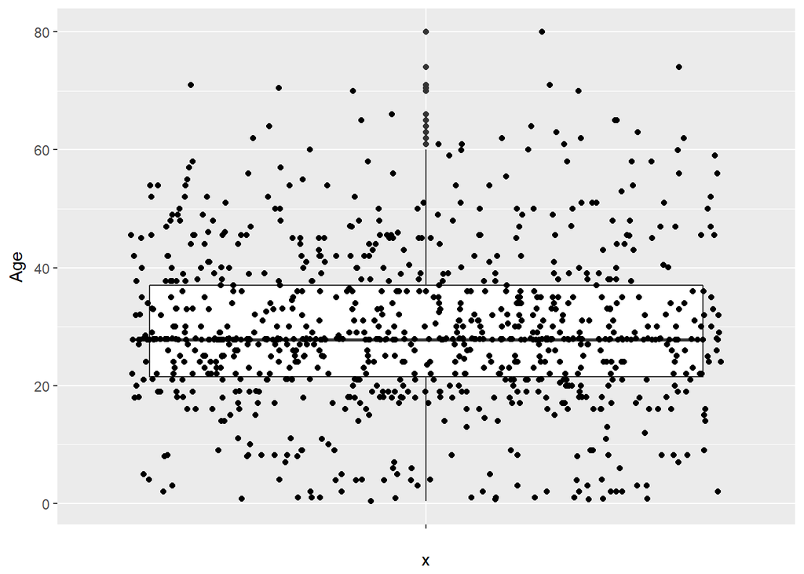

```r
ggplot(data = titanic, aes(x = "", y = Age) ) +
  geom_boxplot() +
  geom_jitter()
```

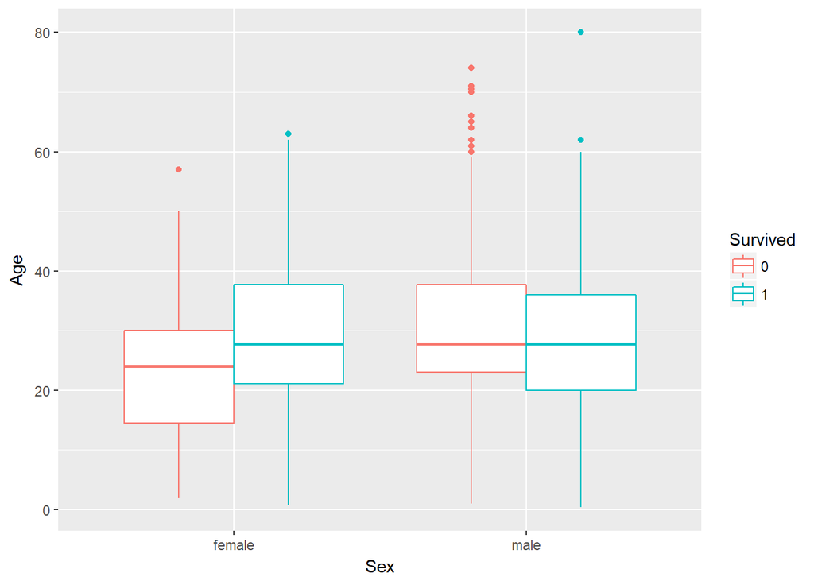

```r
ggplot(data = titanic, aes(x=Sex, y=Age)) +
  geom_boxplot(aes(color=Survived))
```

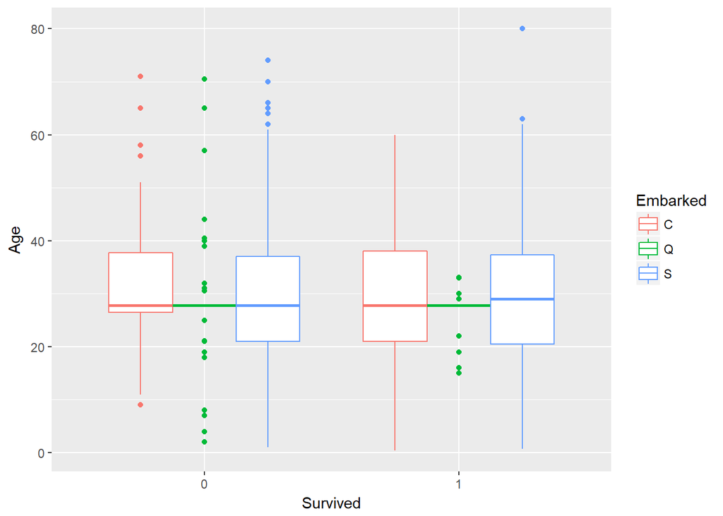

```r
ggplot(data = titanic, aes(x=Survived, y=Age)) +
  geom_boxplot(aes(color= Embarked))
```

Precebe-se a maior quantidade de pessoas entre 21 e 37 anos. Das mulheres, observa-se uma pequena diferença de idade entre as sobreviventes e as que faleceram. Entre os homens, a média de idades é a mesma, alterando apenas levemente a distribuição ao redor da média entre o primeiro e o terceiro quartil.

#### Curiosidade:

O ultimo gráfico indica, dentre vivos e falecidos, qual a variação das idades separando os passageiros por seus portões de embarque.

### Scatterplot (Age ~Survived)

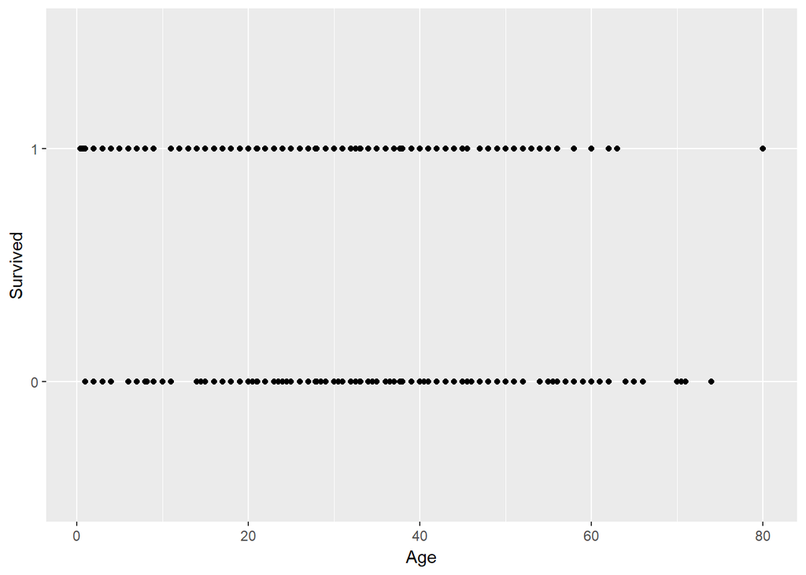

```r
ggplot(data = titanic) +
  geom_point(mapping = aes(x = Age, y = Survived))
```

### Scatterplot (Age ~Embarked)

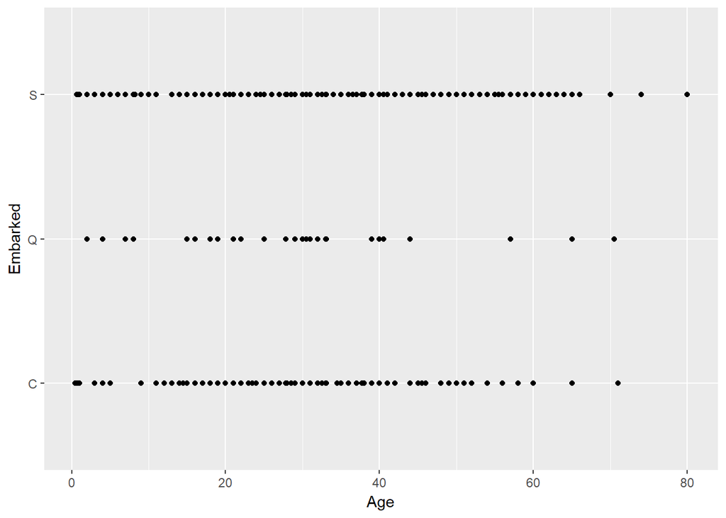

```r
ggplot(data = titanic) +
  geom_point(mapping = aes(x = Age, y = Embarked))
```

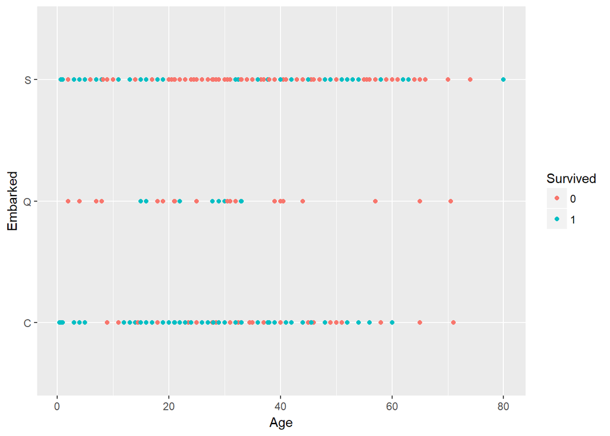

```r
ggplot(data = titanic) +
  geom_point(mapping = aes(x = Age, y = Embarked, color = Survived))
```

### Scatterplot (Sex ~ Age)

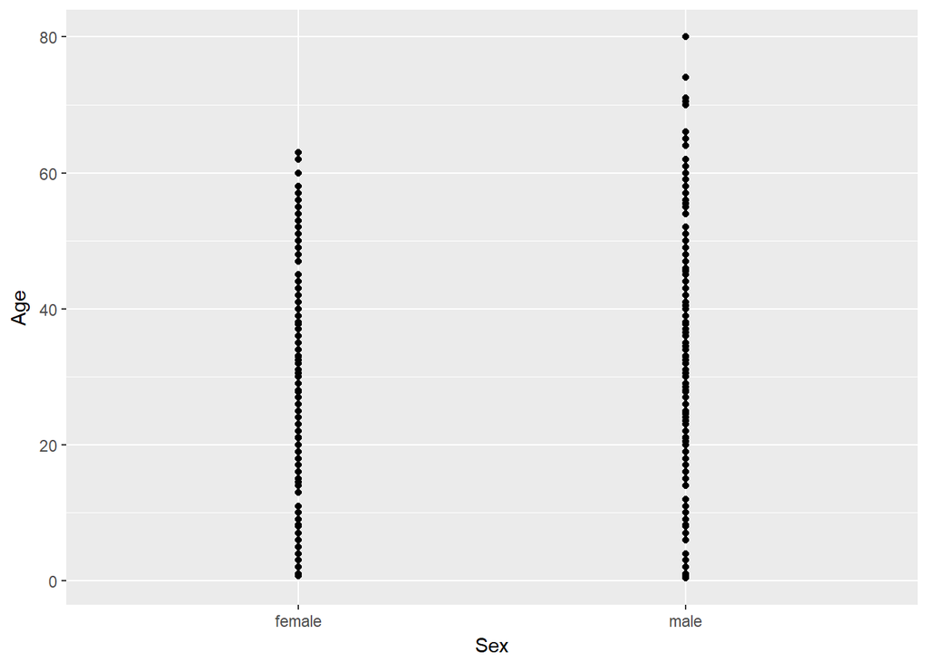

```r
ggplot(data = titanic) +
  geom_point(mapping = aes(x = Sex, y = Age))
```

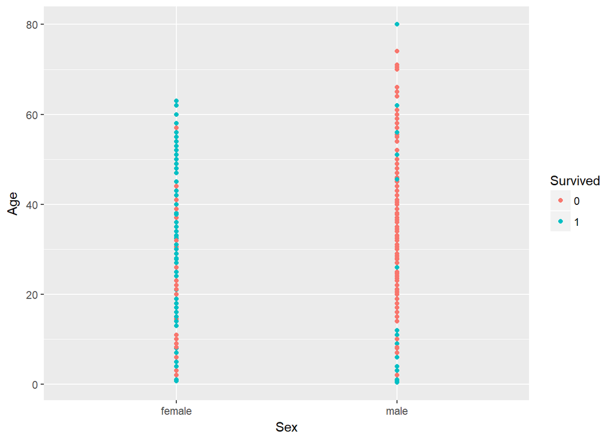

```r
ggplot(data = titanic) +
  geom_point(mapping = aes(x = Sex, y = Age, color = Survived))
```

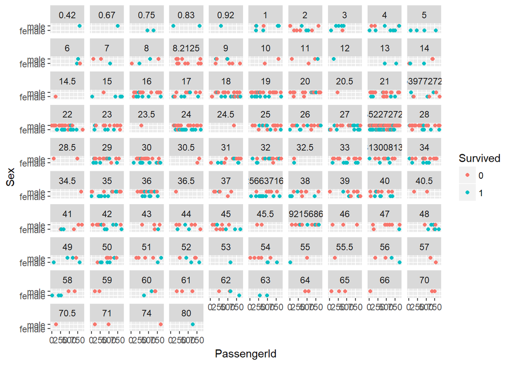

```r
ggplot(data = titanic) +
  geom_point(mapping = aes(x = PassengerId, y = Sex, color = Survived)) +
  facet_wrap( ~ Age )
```

Maior quantidade de mulheres sobreviventes.

### Density

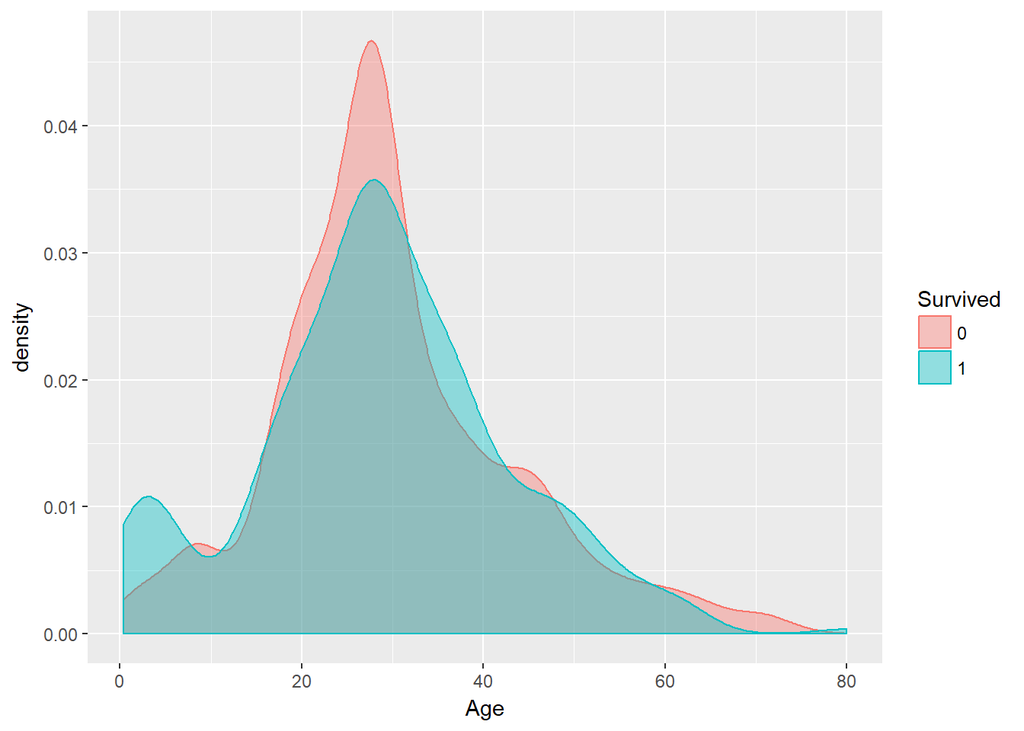

```r
ggplot(data = titanic, aes(Age)) +
  geom_density(aes(fill=Survived,color=Survived), alpha=0.4)
```

### Histogram

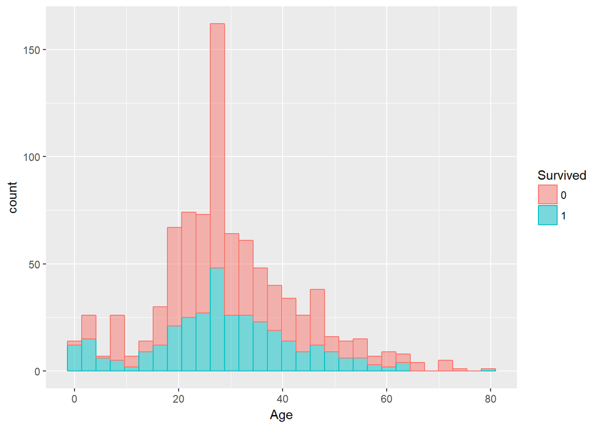

```r
ggplot(data = titanic, aes(Age)) +
  geom_histogram(aes(color=Survived, fill=Survived), alpha=0.5)
```